# Classification

Decision Tree, Random Forest, Perceptron

Eduardo Moreno Ortigosa, Illinois Institute of Technology

## Problem 1. Decision Tree classification 1994 USCensus datasets.

```r
################################################################################################
########################################## EXERCISE 1 ##########################################
###############################################################################################
```

First, the working directory is set to the appropiated along with the seed. Previously, the features of the data are studied with head and str commands.

```r
directory <- getwd()
setwd(directory)

set.seed(1122)

df.train <- read.csv("adult-train.csv")
df.test <- read.csv("adult-test.csv")

head(df.train)
```

|  | age | workclass | fnlwgt | education | education_num | marital_status | occupation | relationship | race | sex | capital_gain | capital_loss | hours_per_week | native_country | income |
| --- | --- | --- | --- | --- | --- | --- | --- | --- | --- | --- | --- | --- | --- | --- | --- |
| 1 | 39 | State-gov | 77516 | Bachelors | 13 | Never-married | Adm-clerical | Not-in-family | White | Male | 2174 | 0 | 40 | United-States | <=50K |
| 2 | 50 | Self-emp-not-inc | 83311 | Bachelors | 13 | Married-civ-spouse | Exec-managerial | Husband | White | Male | 0 | 0 | 13 | United-States | <=50K |
| 3 | 38 | Private | 215646 | HS-grad | 9 | Divorced | Handlers-cleaners | Not-in-family | White | Male | 0 | 0 | 40 | United-States | <=50K |
| 4 | 53 | Private | 234721 | 11th | 7 | Married-civ-spouse | Handlers-cleaners | Husband | Black | Male | 0 | 0 | 40 | United-States | <=50K |
| 5 | 28 | Private | 338409 | Bachelors | 13 | Married-civ-spouse | Prof-specialty | Wife | Black | Female | 0 | 0 | 40 | Cuba | <=50K |
| 6 | 37 | Private | 284582 | Masters | 14 | Married-civ-spouse | Exec-managerial | Wife | White | Female | 0 | 0 | 40 | United-States | <=50K |

```r
str(df.train)
```

```
'data.frame':   32560 obs. of  15 variables:
 $ age           : int  39 50 38 53 28 37 49 52 31 42 ...
 $ workclass     : Factor w/ 9 levels "?","Federal-gov",..: 8 7 5 5 5 5 5 7 5 5 ...
 $ fnlwgt        : int  77516 83311 215646 234721 338409 284582 160187 209642 45781 159449 ...
 $ education     : Factor w/ 16 levels "10th","11th",..: 10 10 12 2 10 13 7 12 13 10 ...
 $ education_num : int  13 13 9 7 13 14 5 9 14 13 ...
 $ marital_status: Factor w/ 7 levels "Divorced","Married-AF-spouse",..: 5 3 1 3 3 3 4 3 5 3 ...
 $ occupation    : Factor w/ 15 levels "?","Adm-clerical",..: 2 5 7 7 11 5 9 5 11 5 ...
 $ relationship  : Factor w/ 6 levels "Husband","Not-in-family",..: 2 1 2 1 6 6 2 1 2 1 ...
 $ race          : Factor w/ 5 levels "Amer-Indian-Eskimo",..: 5 5 5 3 3 5 3 5 5 5 ...
 $ sex           : Factor w/ 2 levels "Female","Male": 2 2 2 2 1 1 1 2 1 2 ...
 $ capital_gain  : int  2174 0 0 0 0 0 0 0 14084 5178 ...
 $ capital_loss  : int  0 0 0 0 0 0 0 0 0 0 ...
 $ hours_per_week: int  40 13 40 40 40 40 16 45 50 40 ...
 $ native_country: Factor w/ 41 levels "?","Cambodia",..: 39 39 39 39 6 39 23 39 39 39 ...
 $ income        : Factor w/ 2 levels "<=50K",">50K": 1 1 1 1 1 1 1 2 2 2 ...
```

### EDA. Removing the “?”.

To remove the “?” character, it is looked the output of str command to check in which features this character exists. For the train data, the character is removed as follows:

```r
##### train #####
sum(df.train == "?")
```

```
[1] 4262
```

```r
colnames(df.train)
```

```
 [1] "age"            "workclass"      "fnlwgt"         "education"      "education_num"
 [6] "marital_status" "occupation"     "relationship"   "race"           "sex"
[11] "capital_gain"   "capital_loss"   "hours_per_week" "native_country" "income"
```

```r
str(df.train) # With str it is possible to view the features with ?
```

```
'data.frame':   32560 obs. of  15 variables:
 $ age           : int  39 50 38 53 28 37 49 52 31 42 ...
 $ workclass     : Factor w/ 9 levels "?","Federal-gov",..: 8 7 5 5 5 5 5 7 5 5 ...
 $ fnlwgt        : int  77516 83311 215646 234721 338409 284582 160187 209642 45781 159449 ...
 $ education     : Factor w/ 16 levels "10th","11th",..: 10 10 12 2 10 13 7 12 13 10 ...
 $ education_num : int  13 13 9 7 13 14 5 9 14 13 ...
 $ marital_status: Factor w/ 7 levels "Divorced","Married-AF-spouse",..: 5 3 1 3 3 3 4 3 5 3 ...
 $ occupation    : Factor w/ 15 levels "?","Adm-clerical",..: 2 5 7 7 11 5 9 5 11 5 ...
 $ relationship  : Factor w/ 6 levels "Husband","Not-in-family",..: 2 1 2 1 6 6 2 1 2 1 ...
 $ race          : Factor w/ 5 levels "Amer-Indian-Eskimo",..: 5 5 5 3 3 5 3 5 5 5 ...
 $ sex           : Factor w/ 2 levels "Female","Male": 2 2 2 2 1 1 1 2 1 2 ...
 $ capital_gain  : int  2174 0 0 0 0 0 0 0 14084 5178 ...
 $ capital_loss  : int  0 0 0 0 0 0 0 0 0 0 ...
 $ hours_per_week: int  40 13 40 40 40 40 16 45 50 40 ...
 $ native_country: Factor w/ 41 levels "?","Cambodia",..: 39 39 39 39 6 39 23 39 39 39 ...
 $ income        : Factor w/ 2 levels "<=50K",">50K": 1 1 1 1 1 1 1 2 2 2 ...
```

```r
sum(df.train$workclass == "?")
```

```
[1] 1836
```

```r
sum(df.train$occupation == "?")
```

```
[1] 1843
```

```r
sum(df.train$native_country == "?")
```

```
[1] 583
```

```r
rows.to.rm.train <- c(which(df.train$workclass == "?"),
                    which(df.train$occupation == "?"),
                    which(df.train$native_country == "?"))

df.train <- df.train[-rows.to.rm.train, ]
sum(df.train == "?")
```

```
[1] 0
```

```r
dim(df.train)
```

```
[1] 30161    15
```

Identically, for the test data the character “?” is studied and removed in the same way:

```r
##### test #####

sum(df.test == "?")
```

```
[1] 2203
```

```r
str(df.test)
```

```
'data.frame':   16281 obs. of  15 variables:
 $ age           : int  25 38 28 44 18 34 29 63 24 55 ...
 $ workclass     : Factor w/ 9 levels "?","Federal-gov",..: 5 5 3 5 1 5 1 7 5 5 ...
 $ fnlwgt        : int  226802 89814 336951 160323 103497 198693 227026 104626 369667 104996 ...
 $ education     : Factor w/ 16 levels "10th","11th",..: 2 12 8 16 16 1 12 15 16 6 ...
 $ education_num : int  7 9 12 10 10 6 9 15 10 4 ...
 $ marital_status: Factor w/ 7 levels "Divorced","Married-AF-spouse",..: 5 3 3 3 5 5 5 3 5 3 ...
 $ occupation    : Factor w/ 15 levels "?","Adm-clerical",..: 8 6 12 8 1 9 1 11 9 4 ...
 $ relationship  : Factor w/ 6 levels "Husband","Not-in-family",..: 4 1 1 1 4 2 5 1 5 1 ...
 $ race          : Factor w/ 5 levels "Amer-Indian-Eskimo",..: 3 5 5 3 5 5 3 5 5 5 ...
 $ sex           : Factor w/ 2 levels "Female","Male": 2 2 2 2 1 2 2 2 1 2 ...
 $ capital_gain  : int  0 0 0 7688 0 0 0 3103 0 0 ...
 $ capital_loss  : int  0 0 0 0 0 0 0 0 0 0 ...
 $ hours_per_week: int  40 50 40 40 30 30 40 32 40 10 ...
 $ native_country: Factor w/ 41 levels "?","Cambodia",..: 39 39 39 39 39 39 39 39 39 39 ...
 $ income        : Factor w/ 2 levels "<=50K",">50K": 1 1 2 2 1 1 1 2 1 1 ...
```

```r
sum(df.test$workclass == "?")
```

```
[1] 963
```

```r
sum(df.test$occupation == "?")
```

```
[1] 966
```

```r
sum(df.test$native_country == "?")
```

```
[1] 274
```

```r
rows.to.rm.test <- c(which(df.test$workclass == "?"),
                      which(df.test$occupation == "?"),
                      which(df.test$native_country == "?"))

df.test <- df.test[-rows.to.rm.test, ]
sum(df.test == "?")
```

```
[1] 0
```

```r
dim(df.test)
```

```
[1] 15060    15
```

### Building a Decision Tree.

#### Decision Tree model.

First of all, it is necessary to install the packages:

```r
#install.packages("rpart")
#install.packages("rpart.plot")
```

```r
library("rpart")
library("rpart.plot")
help(rpart)
```

The decision tree model is induced with rpart

```r
model <- rpart(income ~. ,data=df.train, method = "class")
```

#### Visual Analysis.

Then the model is plotted as shown:

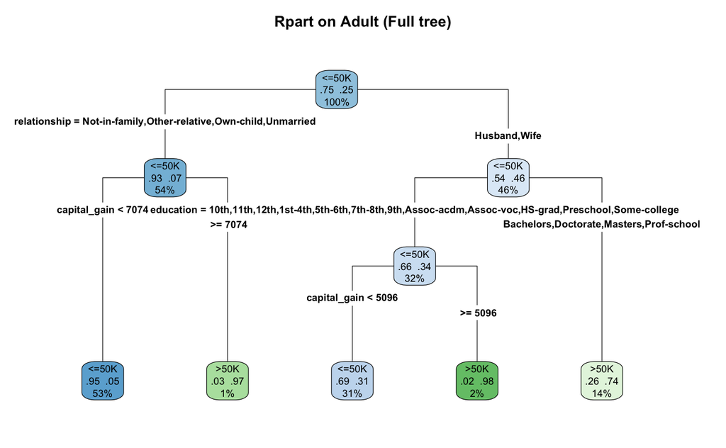

```r
rpart.plot(model, extra = 104, fallen.leaves = T, type = 4, main = "Rpart on Adult (Full tree)")
```

#### Most important predictors of the model.

To see what are the most importat predictors, they should be at the top os the tree. By creating a summary of the model, it results:

```r
summary(model)
```

```
Call:
rpart(formula = income ~ ., data = df.train, method = "class")
  n= 30161

          CP nsplit rel error    xerror        xstd
1 0.12999467      0 1.0000000 1.0000000 0.010001793
2 0.06419819      2 0.7400107 0.7400107 0.008966969
3 0.03729355      3 0.6758125 0.6758125 0.008652716
4 0.01000000      4 0.6385189 0.6385189 0.008457392

Variable importance
  relationship marital_status   capital_gain      education  education_num            sex
            24             23             10              9              9              8
    occupation            age hours_per_week
             7              5              3

Node number 1: 30161 observations,    complexity param=0.1299947
  predicted class=<=50K  expected loss=0.2489307  P(node) =1
    class counts: 22653  7508
   probabilities: 0.751 0.249
  left son=2 (16292 obs) right son=3 (13869 obs)
  Primary splits:
      relationship   splits as  RLLLLR, improve=2277.164, (0 missing)
      marital_status splits as  LRRLLLL, improve=2244.398, (0 missing)
      capital_gain   < 5119   to the left,  improve=1540.825, (0 missing)
      education      splits as  LLLLLLLLLRRLRLRL, improve=1193.769, (0 missing)
      education_num  < 12.5   to the left,  improve=1193.769, (0 missing)
  Surrogate splits:
      marital_status splits as  LRRLLLL, agree=0.993, adj=0.984, (0 split)
      sex            splits as  LR, agree=0.691, adj=0.328, (0 split)
      age            < 33.5   to the left,  agree=0.645, adj=0.229, (0 split)
      occupation     splits as  -LLRRRLLLLRRLLR, agree=0.620, adj=0.175, (0 split)
      hours_per_week < 43.5   to the left,  agree=0.604, adj=0.138, (0 split)

Node number 2: 16292 observations,    complexity param=0.03729355
  predicted class=<=50K  expected loss=0.06966609  P(node) =0.5401678
    class counts: 15157  1135
   probabilities: 0.930 0.070
  left son=4 (15992 obs) right son=5 (300 obs)
  Primary splits:
```

[output cut: 45 more lines]

```

Node number 7: 4150 observations
  predicted class=>50K   expected loss=0.2648193  P(node) =0.1375949
    class counts:  1099  3051
   probabilities: 0.265 0.735

Node number 12: 9219 observations
  predicted class=<=50K  expected loss=0.3070832  P(node) =0.3056596
    class counts:  6388  2831
   probabilities: 0.693 0.307

Node number 13: 500 observations
  predicted class=>50K   expected loss=0.018  P(node) =0.0165777
    class counts:     9   491
   probabilities: 0.018 0.982
```

```r
model$variable.importance[1:3]
```

```
  relationship marital_status   capital_gain
     2277.1638      2241.5344       972.6993
```

Therefore, the most important predictors (as it is said in the summary) are “relationship”, “marital_status” and “capital_gain”.

#### Conclusions.

```r
rownames(model$splits)[1]
```

```
[1] "relationship"
```

Thus the first split is done on the predictor “relationship”.

To know the predicted class of first node, it is observed in the decision tree plot which is “<=50K” class.

### Predict the test dataset.

First, the model is created and the test data is studied.

```r
prediction <- predict(model, df.test, type = "class")

dim(prediction)
```

```r
str(prediction)
```

```
 Factor w/ 2 levels "<=50K",">50K": 1 1 1 2 1 2 1 1 2 2 ...
 - attr(*, "names")= chr [1:15060] "1" "2" "3" "4" ...
```

```r
length(prediction)
```

```
[1] 15060
```

```r
length(df.test$income)
```

```
[1] 15060
```

```r
str(df.test)
```

```
'data.frame':   15060 obs. of  15 variables:
 $ age           : int  25 38 28 44 34 63 24 55 65 36 ...
 $ workclass     : Factor w/ 9 levels "?","Federal-gov",..: 5 5 3 5 5 7 5 5 5 2 ...
 $ fnlwgt        : int  226802 89814 336951 160323 198693 104626 369667 104996 184454 212465 ...
 $ education     : Factor w/ 16 levels "10th","11th",..: 2 12 8 16 1 15 16 6 12 10 ...
 $ education_num : int  7 9 12 10 6 15 10 4 9 13 ...
 $ marital_status: Factor w/ 7 levels "Divorced","Married-AF-spouse",..: 5 3 3 3 5 3 5 3 3 3 ...
 $ occupation    : Factor w/ 15 levels "?","Adm-clerical",..: 8 6 12 8 9 11 9 4 8 2 ...
 $ relationship  : Factor w/ 6 levels "Husband","Not-in-family",..: 4 1 1 1 2 1 5 1 1 1 ...
 $ race          : Factor w/ 5 levels "Amer-Indian-Eskimo",..: 3 5 5 3 5 5 5 5 5 5 ...
 $ sex           : Factor w/ 2 levels "Female","Male": 2 2 2 2 2 2 1 2 2 2 ...
 $ capital_gain  : int  0 0 0 7688 0 3103 0 0 6418 0 ...
 $ capital_loss  : int  0 0 0 0 0 0 0 0 0 0 ...
 $ hours_per_week: int  40 50 40 40 30 32 40 10 40 40 ...
 $ native_country: Factor w/ 41 levels "?","Cambodia",..: 39 39 39 39 39 39 39 39 39 39 ...
 $ income        : Factor w/ 2 levels "<=50K",">50K": 1 1 2 2 1 2 1 1 2 1 ...
```

```r
#install.packages("caret")
library("caret")
#install.packages('e1071')
#install.packages("lattice")
```

The Confusion Matrix is created and the questions answered in next sections.

```r
confusionMatrix(prediction, df.test$income)
```

```
Confusion Matrix and Statistics

          Reference
Prediction <=50K  >50K
     <=50K 10772  1837
     >50K    588  1863

               Accuracy : 0.839
                 95% CI : (0.833, 0.8448)
    No Information Rate : 0.7543
    P-Value [Acc > NIR] : < 2.2e-16

                  Kappa : 0.5098

 Mcnemar's Test P-Value : < 2.2e-16

            Sensitivity : 0.9482
            Specificity : 0.5035
         Pos Pred Value : 0.8543
         Neg Pred Value : 0.7601
             Prevalence : 0.7543
         Detection Rate : 0.7153
   Detection Prevalence : 0.8373
      Balanced Accuracy : 0.7259

       'Positive' Class : <=50K
```

#### Balanced Accuracy.

Balanced Accuracy 0.726 (average of Sensivity and Specificity).

#### Balanced Error Rate

Balanced Error Rate = 1 - Balanced Accuracy = 1 - 0.726 = 0.274

#### Sensitivity and Specificity.

Sensivity = 0.9482 Specificity = 0.5035

#### ROC CURVE. AUC of the curve.

```r
#install.packages("ROCR")
#install.packages("gplots")
library("gplots")
library("ROCR")
```

The ROC plot is performed with y label as True positive rate and x label as False positive rate.

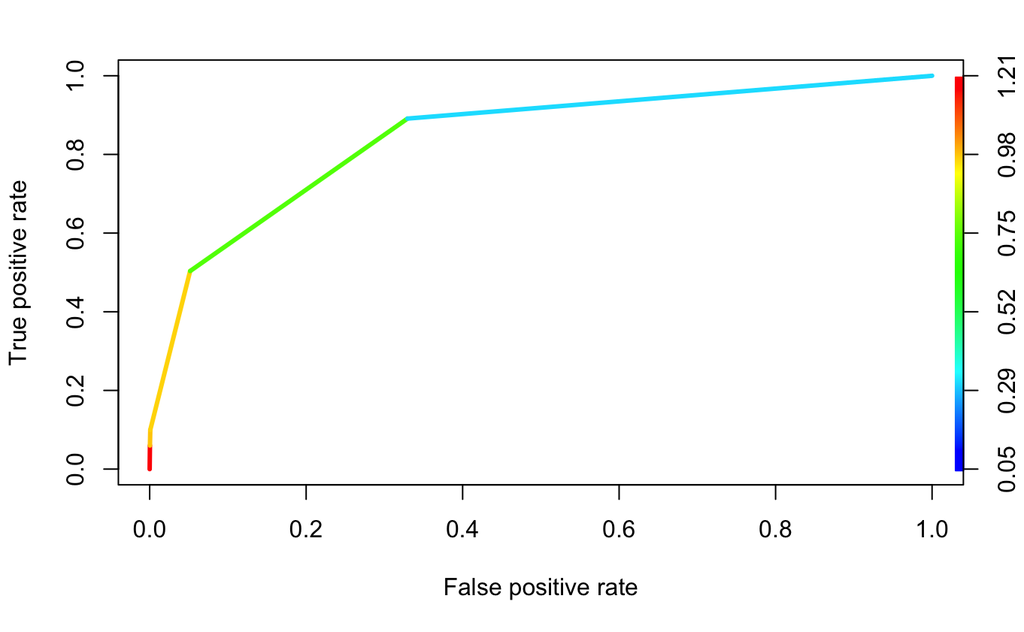

```r
# ROC curve
prediction.rocr <- predict(model, newdata=df.test, type="prob")[,2]
f.pred <- prediction(prediction.rocr, df.test$income)
f.perf <- performance(f.pred, "tpr", "fpr")
plot(f.perf, colorize=T, lwd=3)
```

```r
#Area AUC
auc <- performance(f.pred, measure = "auc")
auc@y.values[[1]][1]
```

```
[1] 0.8430734
```

The area of AUC is 0.843. Since the area of AUC is high, tht is, it is close to 1 (maximum); the ROC curve shows that the model fits well the data. This is due to the fact that the best possible result is a ROC curve with zero false positive rate and 1 true positive rate (top left corner).

### Class imbalance problem. Undersampling.

#### EDA.

```r
print(sum(df.train$income == "<=50K"))
```

```
[1] 22653
```

```r
print(sum(df.train$income == ">50K"))
```

```
[1] 7508
```

The total number of observation of “<=50K” class is 22653 and the total number of “>50K” is 7508. Therefore, it is showed that the dataset is unbalanced.

#### Sample method. Creating a new training set.

The lowest number of class of the income feature is “>50K” therefore, the number of samples to use with sample funtion should be “>50K”.

```r
less.50 <- which(df.train$income == "<=50K")
greater.50 <- which(df.train$income == ">50K")

sample.less.50 <- sample(less.50, length(greater.50))
sample.greater.50 <- sample(greater.50, length(greater.50))
```

The new dataset of training data will be:

```r
new.df.train <- df.train[c(sample.less.50, sample.greater.50), ]
```

The total number of each class

```r
sum(new.df.train$income == "<=50K")
```

```
[1] 7508
```

```r
sum(new.df.train$income == ">50K")
```

```
[1] 7508
```

The total number of observation of “<=50K” is 7508 and the class “>50K” is 7508. The majority class is undersampled (both classes have the same number of observations in the train dataset) and the imbalance problem should be solved.

### Training the new undersampled model.

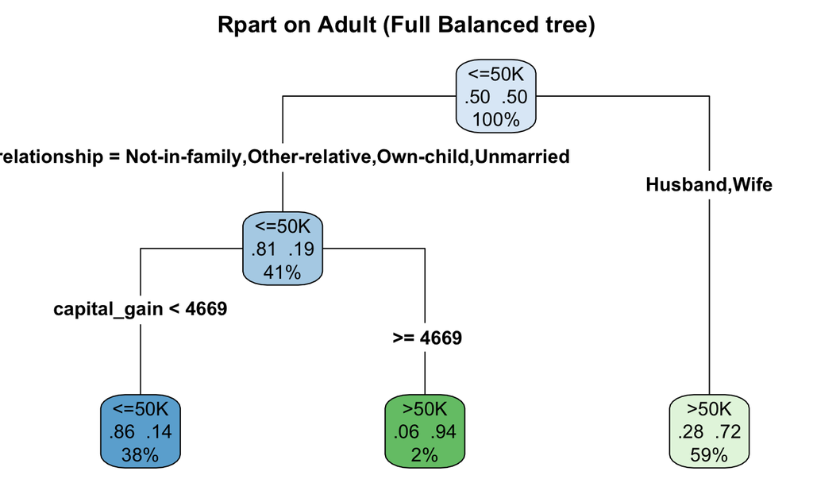

```r
new.model <- rpart(income ~. ,data=new.df.train, method = "class")
rpart.plot(new.model, extra = 104, fallen.leaves = T, type = 4,
           main = "Rpart on Adult (Full Balanced tree)")
```

It is showed that now the new model is balanced for the root node.

```r
new.prediction <- predict(new.model, df.test, type = "class")
confusionMatrix(new.prediction, df.test$income)
```

```
Confusion Matrix and Statistics

          Reference
Prediction <=50K >50K
     <=50K  7576  385
     >50K   3784 3315

               Accuracy : 0.7232
                 95% CI : (0.716, 0.7303)
    No Information Rate : 0.7543
    P-Value [Acc > NIR] : 1

                  Kappa : 0.4297

 Mcnemar's Test P-Value : <2e-16

            Sensitivity : 0.6669
            Specificity : 0.8959
         Pos Pred Value : 0.9516
         Neg Pred Value : 0.4670
             Prevalence : 0.7543
         Detection Rate : 0.5031
   Detection Prevalence : 0.5286
      Balanced Accuracy : 0.7814

       'Positive' Class : <=50K
```

#### Balanced Accuracy

Balanced Accuracy is 0.7814.

#### Balanced Error Rate

Balanced error rate is 0.2186

#### Sensitivity and Specificity

Sensitivity is 0.6669 Specificity is 0.8959

#### ROC Curve. AUC of the curve

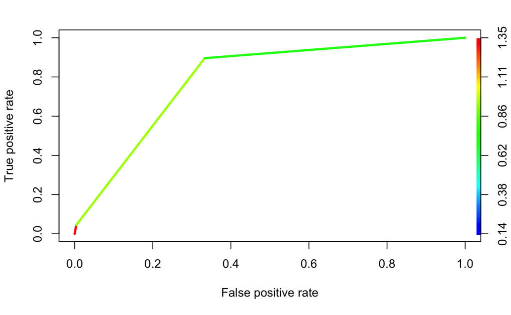

```r
# ROC curve
new.prediction.rocr <- predict(new.model, newdata=df.test, type="prob")[,2]
new.f.pred <- prediction(new.prediction.rocr, df.test$income)
new.f.perf <- performance(new.f.pred, "tpr", "fpr")
plot(new.f.perf, colorize=T, lwd=3)
```

```r
#Area AUC
new.auc <- performance(new.f.pred, measure = "auc")
new.auc@y.values[[1]][1]
```

```
[1] 0.7870369
```

The area of AUC is 0.787, it is still a high value and thus, the model will still fits well the data (even after undersampling).

### Conclusions. Differences between models.

The main difference between the models is the balanced accuracy; the second one solved the problem of unbalanced by an undersampling method. This undersampling may lead into a decrease in the accuracy of the model due to the possibility of lose important observations.

In this case, the sensitivity of the first model is pretty high (close to 1) but the specificity has 0.5 value (due to unbalanced); after solve it the new sensitivity is lower (the number of positive class “<=50” has been decreased) but the specificity higher.

In both cases, the positive predicted value is “<=50” (the first one was going to be obvious since there is a higher number of that samples).

Finally AUC is lower in the balanced model. Due to the change in number of positive class which has been unbalanced it is common that the AUC has changed (the true positive rate and the false positive rate change).

## Problem 2. Random Forest classification 1994 USCensus datasets.

```r
################################################################################################
########################################## EXERCISE 2 ##########################################
###############################################################################################
```

### Building a Random Forest model.

```r
#install.packages("randomForest")
library("randomForest")
```

The random forest model is induced on “income” feature.

```r
randforest.model <- randomForest(income ~ ., data = df.train)
```

Fitting the test dataset into the model.

```r
randforest.prediction <- predict(randforest.model, df.test, type = "class")
```

And the resulting confussion matrix will be

```r
confusionMatrix(randforest.prediction, df.test$income)
```

```
Confusion Matrix and Statistics

          Reference
Prediction <=50K  >50K
     <=50K 10577  1348
     >50K    783  2352

               Accuracy : 0.8585
                 95% CI : (0.8528, 0.864)
    No Information Rate : 0.7543
    P-Value [Acc > NIR] : < 2.2e-16

                  Kappa : 0.5975

 Mcnemar's Test P-Value : < 2.2e-16

            Sensitivity : 0.9311
            Specificity : 0.6357
         Pos Pred Value : 0.8870
         Neg Pred Value : 0.7502
             Prevalence : 0.7543
         Detection Rate : 0.7023
   Detection Prevalence : 0.7918
      Balanced Accuracy : 0.7834

       'Positive' Class : <=50K
```

It seems like there is a problem with unbalanced: the sensitivity has a high value and however it differs enough from specificity.

### Grid Search: ntree, mtry.

```r
list.OOB <- list()
mean.OOB <- c()
list.CM <- list() #List of ConfusionMatrix
list.models <- list()

n <- 1
pos <- 0

for (i in c(100, 750)){
  for (j in c(2, 5, 7)){

    pos = pos + 1
    grid.randForest.model <- randomForest(income ~ ., data = df.train, mtry = j, ntree = i)
    grid.randForest.prediction <- predict(grid.randForest.model, df.test, type ="class")

    grid.OOB <- grid.randForest.model$err.rate[,1]
    grid.CM <- confusionMatrix(grid.randForest.prediction, df.test$income)

    list.models[[n]] <- grid.randForest.model
    list.OOB[[pos]] <- grid.OOB
    mean.OOB[n] <- mean(grid.OOB[[n]])
    list.CM[[pos]] <- grid.CM

    sprintf("Itartion number: %d mtry, %d ntree", j, i)
    n=n + 1
  }
}

summary(list.OOB)
```

```
     Length Class  Mode
[1,] 100    -none- numeric
[2,] 100    -none- numeric
[3,] 100    -none- numeric
[4,] 750    -none- numeric
[5,] 750    -none- numeric
[6,] 750    -none- numeric
```

```r
summary(list.CM)
```

```
     Length Class           Mode
[1,] 6      confusionMatrix list
[2,] 6      confusionMatrix list
[3,] 6      confusionMatrix list
[4,] 6      confusionMatrix list
[5,] 6      confusionMatrix list
[6,] 6      confusionMatrix list
```

### Determining the best model.

```r
for (k in 1:6){
  cat("Model has", list.models[[k]]$mtry, "as mtry and %f ntree",
      list.models[[k]]$ntree, "\n", fill=T)
  cat("1-sensitivity ", list.CM[[k]]$byClass["Sensitivity"],"\n", fill=T)
  cat("2-specificity ", list.CM[[k]]$byClass["Specificity"],"\n", fill=T)
  cat("3-balanced accuracy ", list.CM[[k]]$byClass["Balanced Accuracy"],"\n", fill=T)
}
```

```
Model has 2 as mtry and %f ntree 100

1-sensitivity  0.9347711

2-specificity  0.6294595

3-balanced accuracy  0.7821153

Model has 5 as mtry and %f ntree 100

1-sensitivity  0.9239437

2-specificity  0.6264865

3-balanced accuracy  0.7752151

Model has 7 as mtry and %f ntree 100

1-sensitivity  0.9178697

2-specificity  0.6275676

3-balanced accuracy  0.7727186

Model has 2 as mtry and %f ntree 750

1-sensitivity  0.9337148

2-specificity  0.6337838

3-balanced accuracy  0.7837493

Model has 5 as mtry and %f ntree 750

1-sensitivity  0.9235035

2-specificity  0.6256757

3-balanced accuracy  0.7745896

Model has 7 as mtry and %f ntree 750

1-sensitivity  0.9220951

2-specificity  0.6251351

3-balanced accuracy  0.7736151
```

### Determining the lowest OBB error.

```r
print(mean.OOB)
```

```
[1] 0.1824075 0.1958138 0.1925100 0.1708688 0.1831302 0.1859213
```

```r
sprintf("The minimum OOB is corresponded %f", min(mean.OOB))
```

```
[1] "The minimum OOB is corresponded 0.170869"
```

#### Conclusions. Same models for both?

Yes. In this case both models are the same. I think it should be the case because as the OOB is a measure of the prediction error (which will be lower if the model fits better). However it can be the case where the OOB error does not match with the best model based on the different size of samples and hence, it will be necessary a further analysis and look if an undersampling (or oversampling) is needed.

## Problem 3. Perceptron.

```r
################################################################################################
########################################## EXERCISE 3 ##########################################
###############################################################################################
```

### Reading the datasets.

First, the library where the Support Vector Machines function is located must be called:

```r
library("e1071")
library("ggplot2")
```

The data is loaded.

```r
df.10 <- read.csv("data-10.csv")
df.50 <- read.csv("data-50.csv")
df.500 <- read.csv("data-500.csv")
```

### EDA.

And to begin with the exercise, the data should be study by plotting the dataframes to a fast view of how the data is distributed.

```r
summary(df.10)
```

```
     label           bias         x1               x2
 Min.   :-1.0   Min.   :1   Min.   :0.0100   Min.   :0.0950
 1st Qu.:-1.0   1st Qu.:1   1st Qu.:0.2200   1st Qu.:0.4688
 Median : 1.0   Median :1   Median :0.3665   Median :0.5965
 Mean   : 0.2   Mean   :1   Mean   :0.3566   Mean   :0.5967
 3rd Qu.: 1.0   3rd Qu.:1   3rd Qu.:0.5158   3rd Qu.:0.8480
 Max.   : 1.0   Max.   :1   Max.   :0.6840   Max.   :0.9390
```

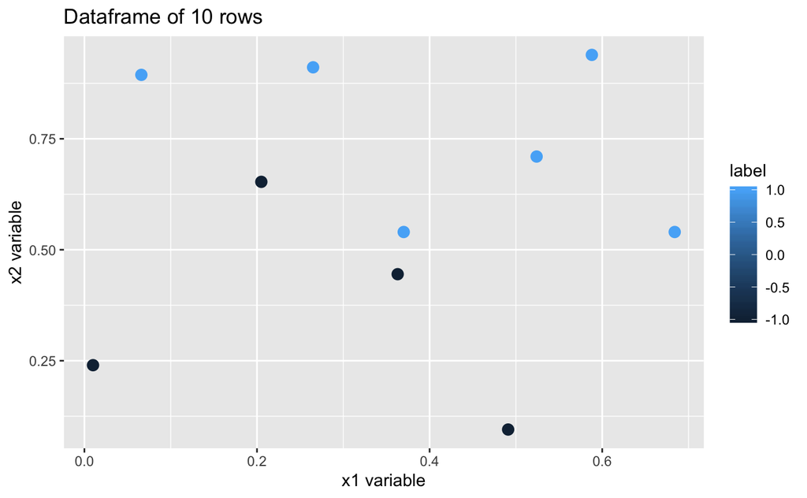

```r
ggplot(df.10, aes(x = x1, y = x2)) +
        geom_point(aes(colour=label), size = 3) +
        xlab("x1 variable") +
        ylab("x2 variable") +
        ggtitle("Dataframe of 10 rows")
```

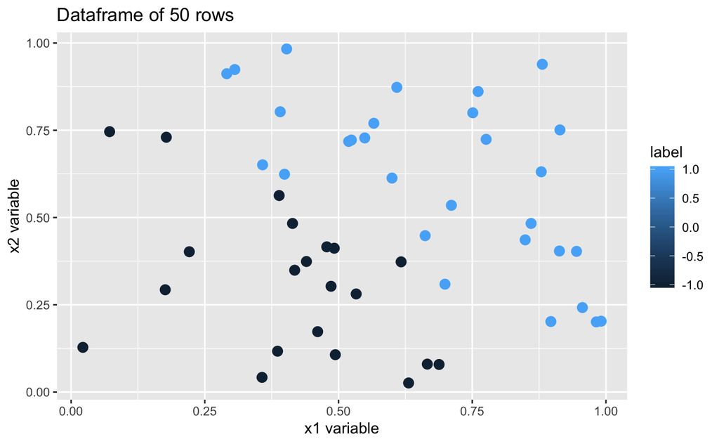

```r
ggplot(df.50, aes(x = x1, y = x2)) +
        geom_point(aes(colour=label), size = 3) +
        xlab("x1 variable") +
        ylab("x2 variable") +
        ggtitle("Dataframe of 50 rows")
```

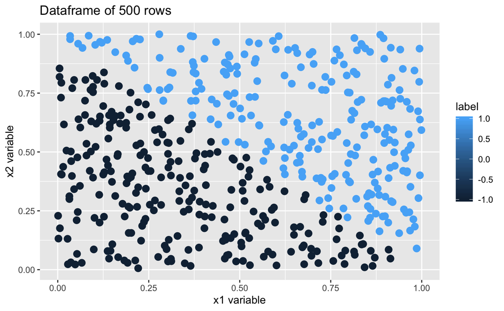

```r
ggplot(df.500, aes(x = x1, y = x2)) +
        geom_point(aes(colour=label), size = 3) +
        xlab("x1 variable") +
        ylab("x2 variable") +
        ggtitle("Dataframe of 500 rows")
```

The perceptron for the three cases is presented as follows. It has been studied a total number of 15 epoch (a number larger enough) in order to know in which epoch the error decrease to zero. In that epoch, the perceptron would have finish and no more iterations are needed.

### 10 observations (easy)

The green line represents the perpendicular line to the resulting vector w which separates the 2 different clases from the dataset.

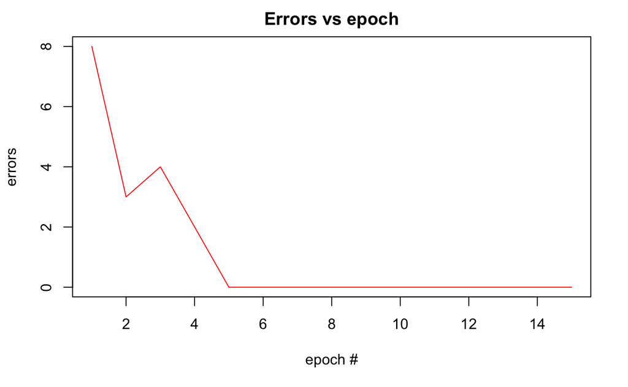

```r
df.10 <- read.csv("data-10.csv")

x <- df.10[,3:4]
y <- df.10[,1]

# Initialize weight vector
w <- rep(0, dim(x)[2] + 1)  #weigth
k <- rep(0, 15)

for (n in 1:15) {

  # All the rows from labels are iterated
  for (i in 1:length(y)) {

    #Activation function based on sign of z
    z <- sum(w[2:length(w)]*x[i, ]) + w[1]

    #If z negative, activation function forces -1 value
    if(z < 0) {
      ypred <- -1
    }
    #Otherwise, it takes the 1 value
    else {
      ypred <- 1
    }

    #Difference of weigth with eta set to 0.5
    w.diff <- 0.5 * (y[i] - ypred) * c(1, as.numeric(x[i, ]))
    w <- w + w.diff

    #The errors will be k
    if ((y[i] - ypred) != 0.0) {
      k[n] <- k[n] + 1
    }
  }
}


plot(1:15, k, type="l", col="red", xlab="epoch #", ylab="errors")
title("Errors vs epoch")
```

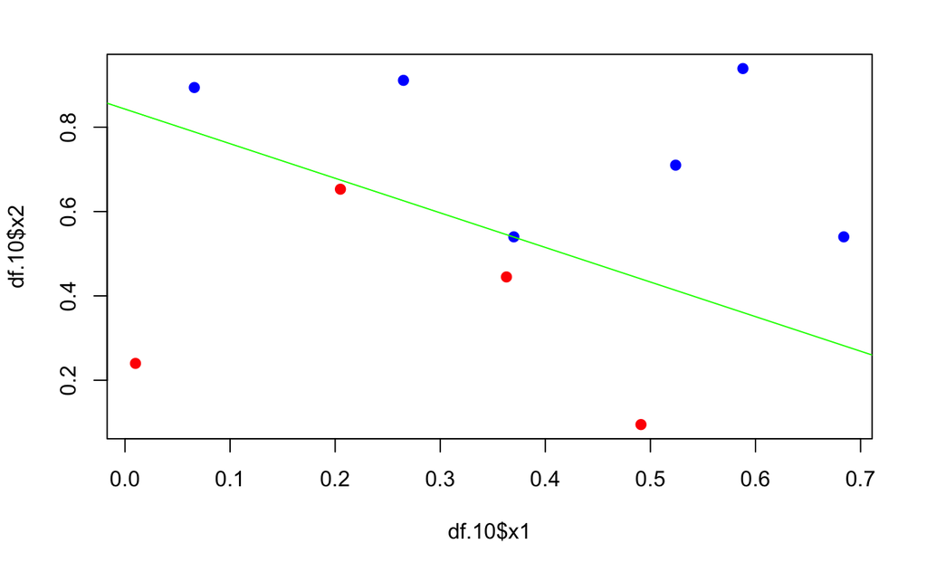

```r
color.df <- df.10
color.df[which(df.10$label!=-1), ] = 4
color.df[which(df.10$label==-1), ] = 10
plot(df.10$x1,df.10$x2, col=color.df$label, pch = 19)
abline(-w[1]/w[3],-w[2]/w[3], col = "green")
```

It is possible to see that in this case, for df.10, the epoch in which the perceptron finish the process is in epoch 5 and thus, no more weights are updated from that point.

### 50 observations (medium)

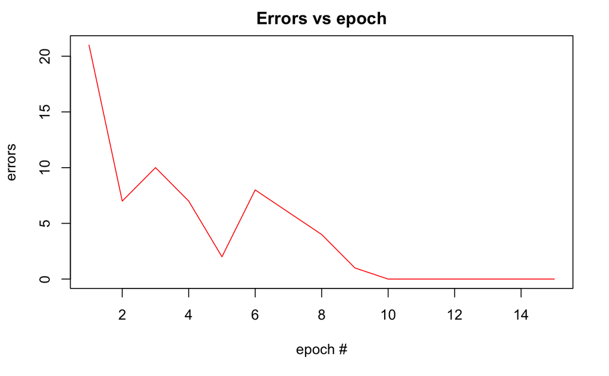

```r
df.50 <- read.csv("data-50.csv")

x <- df.50[,3:4]
y <- df.50[,1]

# Initialize weight vector
w <- rep(0, dim(x)[2] + 1)  #weigth
k <- rep(0, 15)

for (n in 1:15) {

  # All the rows from labels are iterated
  for (i in 1:length(y)) {

    #Activation function based on sign of z
    z <- sum(w[2:length(w)]*x[i, ]) + w[1]

    #If z negative, activation function forces -1 value
    if(z < 0) {
      ypred <- -1
    }
    #Otherwise, it takes the 1 value
    else {
      ypred <- 1
    }

    #Difference of weigth with eta set to 0.5
    w.diff <- 0.5 * (y[i] - ypred) * c(1, as.numeric(x[i, ]))
    w <- w + w.diff

    #The errors will be k
    if ((y[i] - ypred) != 0.0) {
      k[n] <- k[n] + 1
    }
  }
}


plot(1:15, k, type="l", col="red", xlab="epoch #", ylab="errors")
title("Errors vs epoch")
```

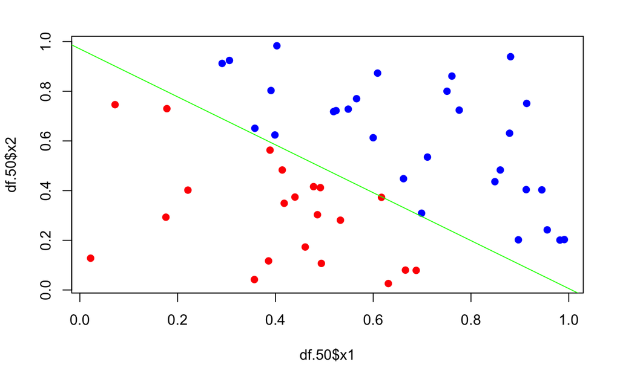

```r
color.df <- df.50
color.df[which(df.50$label!=-1), ] = 4
color.df[which(df.50$label==-1), ] = 10
plot(df.50$x1,df.50$x2, col=color.df$label, pch = 19)
abline(-w[1]/w[3],-w[2]/w[3], col = "green")
```

For this case, the epoch is 10 and no more updates of weight are done from this epoch. Note that there is a point of one label (red point) which yields in the line that separates both sets of points.

### 500 observations (hard)

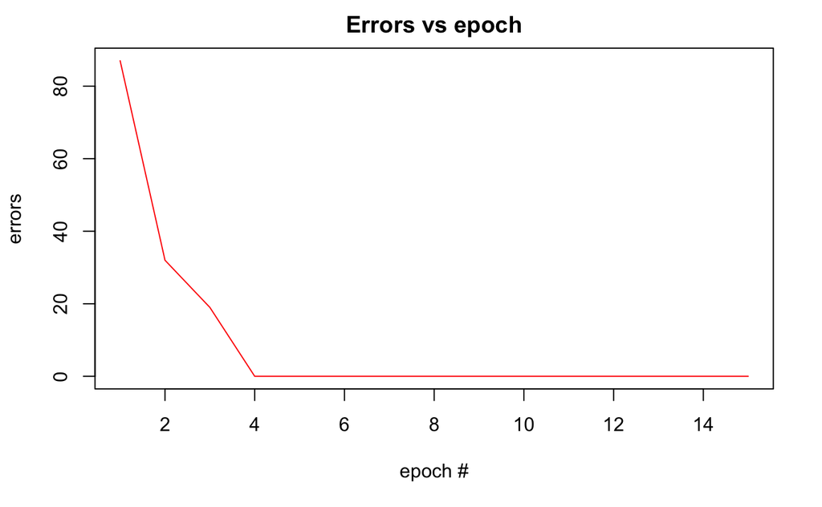

```r
df.500 <- read.csv("data-500.csv")

x <- df.500[,3:4]
y <- df.500[,1]

# initialize weight vector
w <- rep(0, dim(x)[2] + 1)  #weigth
k <- rep(0, 15)



for (n in 1:15) {

  # All the rows from labels are iterated
  for (i in 1:length(y)) {

    #Activation function based on sign of z
    z <- sum(w[2:length(w)]*x[i, ]) + w[1]

    #If z negative, activation function forces -1 value
    if(z < 0) {
      ypred <- -1
    }
    #Otherwise, it takes the 1 value
    else {
      ypred <- 1
    }

    #Difference of weigth with eta set to 0.5
    w.diff <- 0.5 * (y[i] - ypred) * c(1, as.numeric(x[i, ]))
    w <- w + w.diff

    #The errors will be k
    if ((y[i] - ypred) != 0.0) {
      k[n] <- k[n] + 1
    }

  }
}


plot(1:15, k, type="l", col="red", xlab="epoch #", ylab="errors")
title("Errors vs epoch")
```

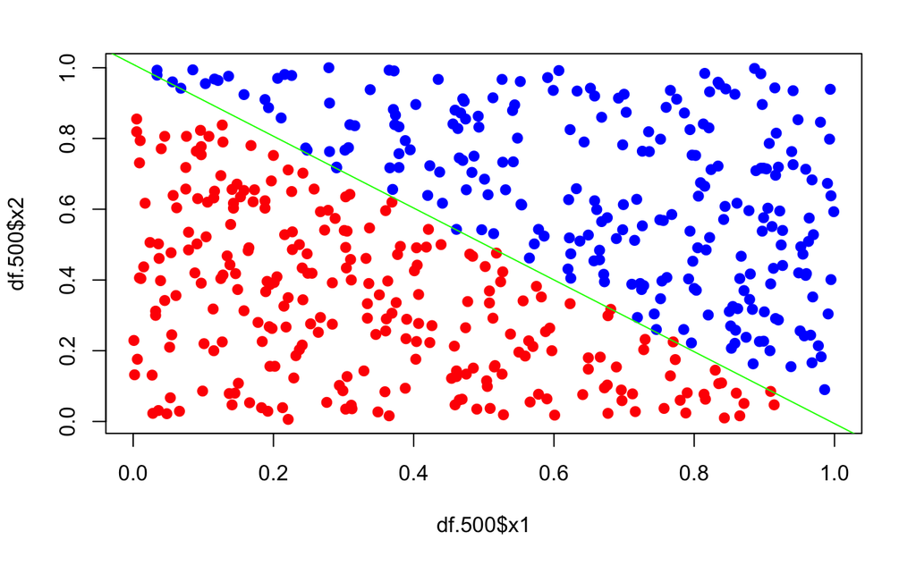

```r
color.df <- df.500
color.df[which(df.500$label!=-1), ] = 4
color.df[which(df.500$label==-1), ] = 10
plot(df.500$x1,df.500$x2, col=color.df$label, pch = 19)
abline(-w[1]/w[3],-w[2]/w[3], col = "green")
```

Finally, for the df.500, the epoch is 4. In this case the error decrease faster. This should be due to the labels that are in the dataset since less iterations are need; the perceptron would find faster the line which delimites both sizes. With higher number of points it will be more common having more points which yield in the green line.